# Homework 1

2024-02-12

#### 1. Dating trends over time

Visualize how the mode of meeting for the first time has changed over the years.

Create two (2) charts in this section to highlight some important pattern(s). Make sure to use some variation in the type of visualization. Briefly discuss which visualization you recommend to your editor and why.

Discuss three specific design choices in these graphs that were influenced by your knowledge of the data visualization principles we discussed in the lectures.

- I’m going to use different colors to distinguish the “meeting type” category. This is an application of pre-noticed visual properties that make it easier for the viewer to quickly distinguish between categories without being conscious.In the first chart, a common scale is used on the Y-axis to make it easier to compare different types of meetings over the years. This is consistent with the principle that length is easier to judge using a common baseline.By avoiding too many categories in the chart, this design ensures that viewers can focus on the most important trends without being overwhelmed. This also reflects Gestalt principles, where simplification helps viewers group and compare patterns more effectively.

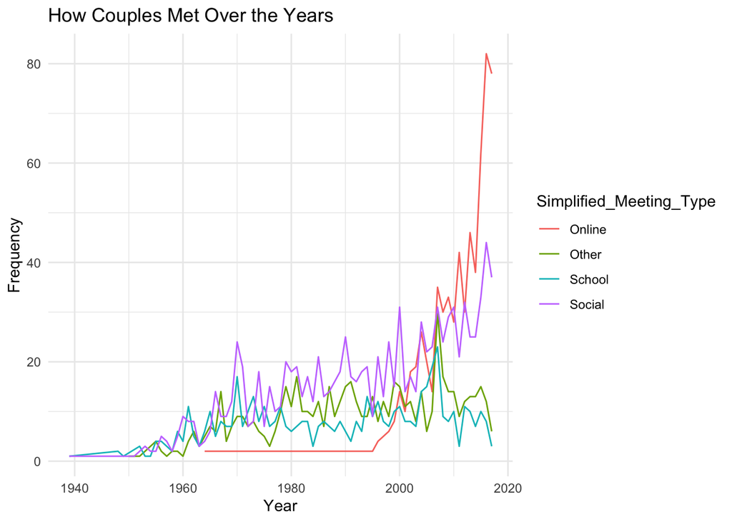

```r
#### Graph 1

library(tidyverse)
hcmst_couples=readRDS("/Users/arabellaliu/Desktop/HCMST_couples.rds")

library(tidyverse)
library(lubridate)

hcmst_couples$Simplified_Meeting_Type <- case_when(
  hcmst_couples$meeting_type %in% c('Internet', 'Internet Dating or Phone App', 'Internet Social Network', 'Online Gaming', 'Internet Chat', 'Internet Site', 'Met Online') ~ 'Online',
  hcmst_couples$meeting_type %in% c('Bar or Restaurant', 'Private Party', 'Public Place', 'Blind Date', 'On Vacation') ~ 'Social',
  hcmst_couples$meeting_type %in% c('Primary or Secondary School', 'College') ~ 'School',
  hcmst_couples$meeting_type %in% c('Military', 'Church', 'Volunteer Organization', 'Customer-Client Relationship') ~ 'Other',
  TRUE ~ 'Other'
)

data_for_viz <- hcmst_couples %>%
  filter(!is.na(Q21A_Year)) %>%
  group_by(Q21A_Year, Simplified_Meeting_Type) %>%
  summarise(Count = n(), .groups = 'drop')

data_for_viz$Q21A_Year <- as.numeric(as.character(data_for_viz$Q21A_Year))
ggplot(data_for_viz, aes(x = Q21A_Year, y = Count, color = Simplified_Meeting_Type)) +
  geom_line() +
  labs(title = "How Couples Met Over the Years", x = "Year", y = "Frequency") +
  theme_minimal()
```

```r
recent_year <- max(data_for_viz$Q21A_Year)
recent_year_data <- filter(data_for_viz, Q21A_Year == recent_year)
```

```r
#### Graph 2

# Convert Q21A_Year to a numeric column
hcmst_couples$Q21A_Year <- as.numeric(as.character(hcmst_couples$Q21A_Year))
data_for_viz <- hcmst_couples %>%
  filter(!is.na(Q21A_Year)) %>%
  group_by(Q21A_Year, Simplified_Meeting_Type) %>%
  summarise(Count = n(), .groups = 'drop')

# I am finding the most recent year
recent_year <- max(data_for_viz$Q21A_Year, na.rm = TRUE)

recent_year_data <- filter(data_for_viz, Q21A_Year == recent_year)

print(recent_year_data)
```

```
## # A tibble: 4 × 3
##   Q21A_Year Simplified_Meeting_Type Count
##       <dbl> <chr>                   <int>
## 1      2017 Online                     78
## 2      2017 Other                       6
## 3      2017 School                      3
## 4      2017 Social                     37
```

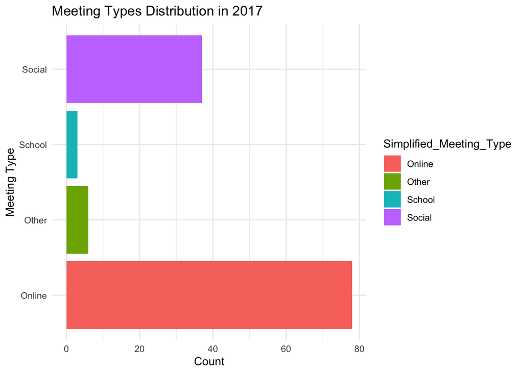

```r
if (nrow(recent_year_data) > 0) {
  ggplot(recent_year_data, aes(x = Simplified_Meeting_Type, y = Count, fill = Simplified_Meeting_Type)) +
    geom_bar(stat = "identity") +
    labs(title = paste("Meeting Types Distribution in", recent_year), x = "Meeting Type", y = "Count") +
    theme_minimal() +
    coord_flip()
} else {
  cat("No data available for the most recent year.")
}
```

#### 2. Age is just a number Create one (1) visualization to show the relationship between a respondent’s age and their partner’s age, accounting for the gender of the respondent? Identify the main pattern in the graph via an annotation directly added to the plot.

[figure not shown]

```r
ggplot(hcmst_couples, aes(x = ppage, y = Q9, color = ppgender)) +
  geom_point(alpha = 0.6) +
  geom_smooth(method = "lm", se = FALSE) +
  labs(title = "Gender relationship between respondent's age and partner's age",
       x = "Respondent's Age",
       y = "Partner's Age") +
  scale_color_manual(values = c("Female" = "skyblue", "Male" = "orange")) +
  theme_minimal() +
  theme(plot.margin = margin(t = 30, r = 30, b = 10, l = 10, unit = "pt")) +
  annotate("text", x = 60, y = 100, label = "Partner's age increases with respondent's, steeper for males", size = 4, color = "red")
```

#### 3. Politics and Dating

Explore how the political affiliation of partners affects how couples meet and stay together.

Create two (2) charts in this section to highlight the information on politics and dating. Make sure to use some variation in the type of visualizations. Discuss which visualization you recommend to your editor and why.

- In my opinion, I would recommend the bear chart because It is immediately apparent how affiliations are distributed and where the biggest differences lie between partners and respondents. Not only that, but also bar chart are widely understood by general audiences, making the first visualization more accessible for a broad readership.

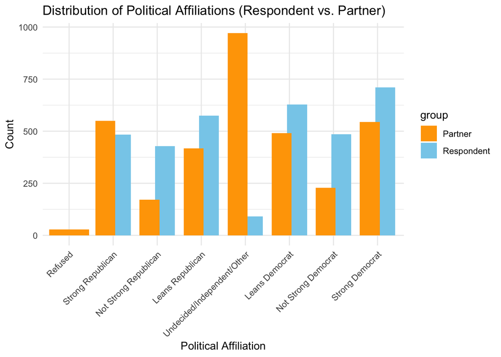

```r
#### CHART 1: Bar chart showing the distribution of political affiliations within the dataset.

library(tidyverse)

df = readRDS("/Users/arabellaliu/Desktop/HCMST_couples.rds")

df$partyid7 <- as.factor(df$partyid7)
df$w6_q12 <- as.factor(df$w6_q12)


respondent_distribution <- df %>%
  count(partyid7) %>%
  rename(affiliation = partyid7, count = n) %>%
  mutate(group = 'Respondent')


partner_distribution <- df %>%
  count(w6_q12) %>%
  rename(affiliation = w6_q12, count = n) %>%
  mutate(group = 'Partner')

combined_distribution <- bind_rows(respondent_distribution, partner_distribution)

# Plot the distribution using ggplot
ggplot(combined_distribution, aes(x = affiliation, y = count, fill = group)) +
  geom_bar(stat = 'identity', position = position_dodge(width = 0.7)) +
  scale_fill_manual(values = c("Respondent" = "skyblue", "Partner" = "orange")) +
  labs(title = "Distribution of Political Affiliations (Respondent vs. Partner)",
       x = "Political Affiliation", y = "Count") +
  theme_minimal() +
  theme(axis.text.x = element_text(angle = 45, hjust = 1))
```

```r
ggsave("political_affiliations_distribution.png", width = 12, height = 8, dpi = 300)
```

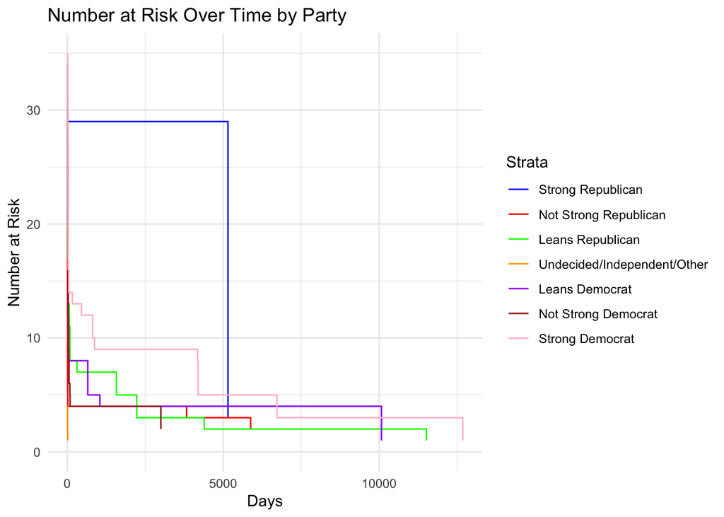

```r
#### line chart
library(ggplot2)
library(survival)
library(dplyr)
df$relationship_ended <- as.numeric(df$w6_relationship_end_nonmar == 'We broke up')
df$duration <- as.numeric(df$duration)
cleaned_data <- df
fit <- coxph(Surv(duration, relationship_ended) ~ w6_q12 + strata(partyid7), data = cleaned_data)

fit.surv <- survfit(fit)


surv_data <- data.frame(Time = numeric(), NumAtRisk = numeric(), Strata = factor())

for(i in seq_along(fit.surv$strata)) {
  strata_name <- names(fit.surv$strata)[i]
  strata_length <- fit.surv$strata[i]
  start_index <- sum(fit.surv$strata[1:(i-1)]) + 1
  end_index <- sum(fit.surv$strata[1:i])

  surv_data <- rbind(surv_data, data.frame(
    Time = fit.surv$time[start_index:end_index],
    NumAtRisk = fit.surv$n.risk[start_index:end_index],
    Strata = as.factor(strata_name)
  ))
}


ggplot(surv_data, aes(x = Time, y = NumAtRisk, color = Strata)) +
  geom_step() +
  labs(x = "Days", y = "Number at Risk", title = "Number at Risk Over Time by Party") +
  scale_color_manual(values = c('blue', 'red', 'green', 'orange', 'purple', 'brown', 'pink')) +
  theme_minimal() +
  scale_y_continuous(limits = c(0, 35))
```

#### 4. Your turn to choose

There are lots of other variables that could make for an interesting story, for example, educational background differences, relationship stages (First Met, Romantic, Live together & Married), regional patterns, relationship break ups, sexual behavior etc. Select some variables of your choice to tell a story that captures an interesting insight into the data.

Create two (2) charts in this section to highlight some important patterns. Make sure to use some variation in the type of visualizations. Briefly discuss which visualization you recommend to your editor, why you think this visualization is useful, and which patterns it serves to highlight.

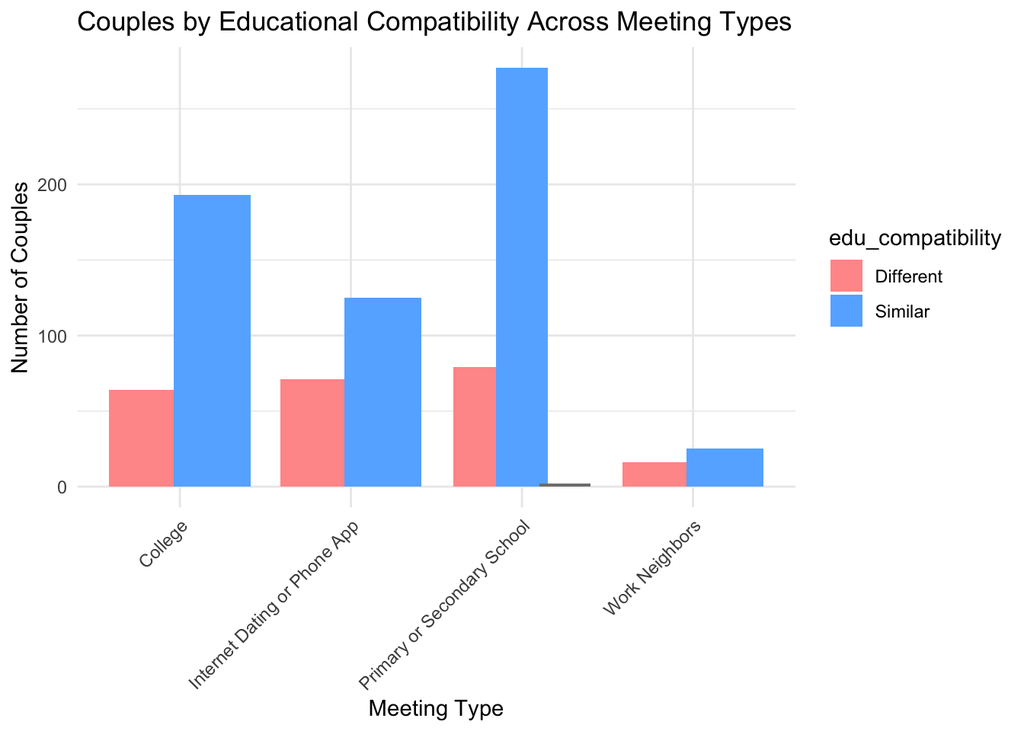

```r
library(tidyverse)


df <- df %>%
  mutate(
    edu_diff = abs(partner_yrsed - subject_yrsed),
    edu_compatibility = ifelse(edu_diff <= 2, "Similar", "Different")
  )

edu_comp_meeting_type <- df %>%
  group_by(meeting_type, edu_compatibility) %>%
  summarise(count = n(), .groups = 'drop')

selected_meeting_types <- c("Internet Dating or Phone App", "College", "Primary or Secondary School", "Work Neighbors")
edu_comp_meeting_type_selected <- edu_comp_meeting_type %>%
  filter(meeting_type %in% selected_meeting_types)

# Create the bar chart
ggplot(edu_comp_meeting_type_selected, aes(x = meeting_type, y = count, fill = edu_compatibility)) +
  geom_bar(stat = "identity", position = position_dodge(width = 0.75)) +
  scale_fill_manual(values = c("Different" = "#ff9999", "Similar" = "#66b3ff")) +
  labs(
    title = "Couples by Educational Compatibility Across Meeting Types",
    x = "Meeting Type",
    y = "Number of Couples"
  ) +
  theme_minimal() +
  theme(axis.text.x = element_text(angle = 45, hjust = 1))
```

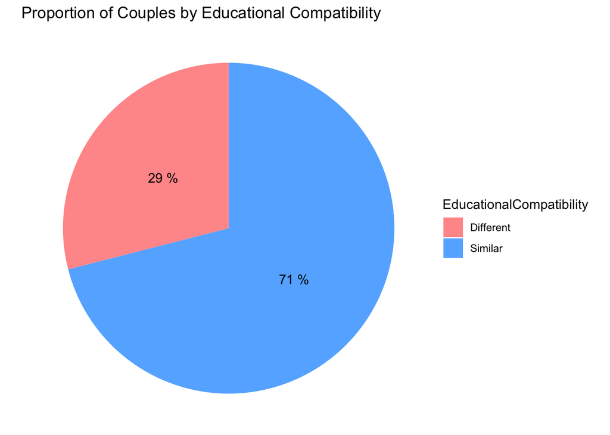

```r
library(ggplot2)

education_data <- data.frame(
  EducationalCompatibility = c("Similar", "Different"),
  Proportion = c(71, 29)
)


pie_chart <- ggplot(education_data, aes(x = "", y = Proportion, fill = EducationalCompatibility)) +
  geom_bar(width = 1, stat = "identity") +
  coord_polar("y", start = 0) +
  scale_fill_manual(values = c("Similar" = "#66b3ff", "Different" = "#ff9999")) +
  theme_void() +
  labs(title = "Proportion of Couples by Educational Compatibility") +
  geom_text(aes(label = paste(Proportion, "%")),
            position = position_stack(vjust = 0.5))

# Display the pie chart
print(pie_chart)
```

```r
#### The chart segments the population into two categories: 71% with a similar educational background and 29% with a different educational background.
```

#### 5. Make two plots interactive

Choose 2 of the plots you created above and add interactivity. For at least one of these interactive plots, this should not be done through the use of `ggplotly`. Briefly describe to the editor why interactivity in these visualizations is particularly helpful for a reader.

- (Bar Charts): The interactivity in these visualizations is particularly helpful for a reader because I can easily compare data from different groups or categories based on this bar chart. In the case of political affiliation, readers can quickly compare the distribution between respondents and their partners, helping to gain a deeper understanding of any similarities or differences.
- (Scatter Plot): In my opinion, interactive elements allow people to hover over data points to see other details. I think this kind of functionality makes it easier for users to identify patterns without having to use a lot of information up front.By interacting with the visualization, the reader can more easily compare data points in different categories or groups. In this case, comparing age relationships by gender becomes more intuitive, as users can selectively focus on male or female data points and their corresponding linear model lines.

```r
library(tidyverse)
library(plotly)
df = readRDS("/Users/arabellaliu/Desktop/HCMST_couples.rds")

df$partyid7 <- as.factor(df$partyid7)
df$w6_q12 <- as.factor(df$w6_q12)

respondent_distribution <- df %>%
  count(partyid7) %>%
  rename(affiliation = partyid7, count = n) %>%
  mutate(group = 'Respondent')

partner_distribution <- df %>%
  count(w6_q12) %>%
  rename(affiliation = w6_q12, count = n) %>%
  mutate(group = 'Partner')

combined_distribution <- bind_rows(respondent_distribution, partner_distribution)

p <- ggplot(combined_distribution, aes(x = affiliation, y = count, fill = group)) +
  geom_bar(stat = 'identity', position = position_dodge(width = 0.7)) +
  scale_fill_manual(values = c("Respondent" = "skyblue", "Partner" = "orange")) +
  labs(title = "Distribution of Political Affiliations (Respondent vs. Partner)",
       x = "Political Affiliation", y = "Count") +
  theme_minimal() +
  theme(axis.text.x = element_text(angle = 45, hjust = 1))

interactive_plot <- ggplotly(p)

print(interactive_plot)
```

[output not shown]

```r
library(plotly)
library(dplyr)

filtered_data <- hcmst_couples %>%
  filter(!is.na(ppage) & !is.na(Q9) & !is.na(ppgender))

female_data <- filtered_data %>% filter(ppgender == "Female")
male_data <- filtered_data %>% filter(ppgender == "Male")

lm_female <- lm(Q9 ~ ppage, data = female_data)
lm_male <- lm(Q9 ~ ppage, data = male_data)


p <- plot_ly() %>%
  # Add points for Female
  add_trace(data = female_data, x = ~ppage, y = ~Q9, type = 'scatter', mode = 'markers',
            marker = list(color = 'skyblue', opacity = 0.6), name = 'Female') %>%
  # Add points for Male
  add_trace(data = male_data, x = ~ppage, y = ~Q9, type = 'scatter', mode = 'markers',
            marker = list(color = 'orange', opacity = 0.6), name = 'Male') %>%
  # Add linear model for Female using filtered data
  add_trace(x = female_data$ppage, y = predict(lm_female, newdata = female_data),
            type = 'scatter', mode = 'lines', line = list(color = 'skyblue'), name = 'LM Female') %>%
  # Add linear model for Male using filtered data
  add_trace(x = male_data$ppage, y = predict(lm_male, newdata = male_data),
            type = 'scatter', mode = 'lines', line = list(color = 'orange'), name = 'LM Male') %>%

  layout(title = "Gender Relationship Between Respondent's Age and Partner's Age",
         xaxis = list(title = "Respondent's Age"),
         yaxis = list(title = "Partner's Age"),
         legend = list(orientation = "h", x = 0.3, y = -0.1),
         hovermode = "closest")
print(p)
```

[output not shown]

#### 6. Data Table

To allow the reader to explore the survey data by themselves a bit, select a few useful variables, rename them appropriately for the table to be self-explanatory, and add an interactive data table to the output. Make sure the columns are clearly labeled. Select the appropriate options for the data table (e.g. search bar, sorting, column filters, in-line visualizations etc.). Suggest to the editor which kind of information you would like to provide in a data table and why.

- Meeting Context provides insight into where and how couples meet. Relationship Value allows readers to see how respondents rate their relationships. This provides greater insight into relationship satisfaction and its correlation with other factors, such as conference background or education level.Year of Education is an important factor in relationships, affecting compatibility, social circles, and even the success of long-term relationships.Interracial Couple is crucial for examining diversity and social integration in relationships. In summary, the purpose of choosing these variables for the data sheet is to allow sociological theories such as the impact of the Internet on social bonding, patterns of same-sex marriage in society, and the dynamics of interracial relationships to be explored in practice, thus making the data more relevant and insightful for the reader.

```r
library(DT)
library(dplyr)

df = readRDS("/Users/arabellaliu/Desktop/HCMST_couples.rds")

df_selected <- df %>%
  select(meeting_type, value, partner_yrsed, subject_yrsed, interracial_5cat, met_through_as_nghbrs, met_as_through_cowork) %>%
  rename(
    `Meeting Context` = meeting_type,
    `Relationship Value` = value,
    `Years of Education (Partner)` = partner_yrsed,
    `Years of Education (Subject)` = subject_yrsed,
    `Interracial Couple` = interracial_5cat,
    `Met as Neighbors` = met_through_as_nghbrs,
    `Met through Work` = met_as_through_cowork
  ) %>%
  mutate(
    `Interracial Couple` = ifelse(`Interracial Couple` == "yes", "Yes", "No"),
    `Met as Neighbors` = ifelse(`Met as Neighbors` == "yes", "Yes", "No"),
    `Met through Work` = ifelse(`Met through Work` == "yes", "Yes", "No")
  )

datatable(df_selected, options = list(pageLength = 5, autoWidth = TRUE))
```

|  | Meeting Context | Relationship Value | Years of Education (Partner) | Years of Education (Subject) | Interracial Couple | Met as Neighbors | Met through Work |
| --- | --- | --- | --- | --- | --- | --- | --- |
| 1 | Primary or Secondary School | yes | 20 | 14 | No | No | No |
| 2 | Primary or Secondary School | yes | 12 | 13 | No | No | No |
| 3 | Primary or Secondary School | yes | 11 | 12 | No | No | No |
| 4 | Primary or Secondary School | yes | 12 | 12 | No | No | No |
| 5 | Primary or Secondary School | yes | 16 | 13 | Yes | No | No |
| 6 | Primary or Secondary School | yes | 14 | 14 | No | No | No |
| 7 | Primary or Secondary School | yes | 14 | 16 | No | No | Yes |
| 8 | Primary or Secondary School | yes | 13 | 13 | No | Yes | No |
| 9 | Primary or Secondary School | yes | 12 | 12 | No | No | No |
| 10 | Primary or Secondary School | yes | 16 | 17 | Yes | No | No |

[output cut: 3391 more lines]